# Análisis Exploratorio de Datos

Tomás Sánchez Grigioni

2020-12-14

## Bibliotecas a utilizar

Encontramos la lista de bibliotecas a utilizar aqui, con el fin de por qué las incluimos. Además, cargamos el archivo que contiene funciones importantes a utilizar.

```r
# Para anaálisis de datos
library(tidyverse)
```

```r
library(lubridate)
```

```r
# Para RMarkdown
library(knitr)
library(kableExtra)
```

```r
library(tinytex)
```

```r
# Para cargar datos
library(readxl)

# Para customizar ggplot
library(ggpubr)
```

```r
library(ggthemes)
library(extrafont)
```

```r
library(scales)
```

```r
# Funciones utiles
source("../R/Utils.R")
```

## Importar los datos

La información de las variables se puede extraer de este [link](https://www.synapse.org/#!Synapse:syn4993293/wiki/390372)

En principio los datos se encontraban divididos en dos BDs diferentes, pero el merge ya se hizo en otro archivo diferente. Comenzamos seleccionando las variables que nos interesan. Observamos como trata a cada variable.

```r
datos_crudos <- read.table("../data/bd_final.csv", sep = ";", dec = ".", header = TRUE)

datos_it0 <- datos_crudos %>%
  select(id,
         edad,
         es_cuidador,
         dbs, anio_diagnostico,
         educ,
         empleo,
         genero,
         tipo_medico,
         estado_marital,
         anio_comienzo_med,
         anio_comienzo_sintomas,
         paquetes_por_dia,
         facilidad_celular,
         fumo,
         cirugia,
         videollamada,
         anios_fumo,
         diagnostico_pro)

# Lo hacemos un poco más complejo para que sea mas legible el output
tibble("Nombre" = names(datos_it0), "Clase" = map_chr(datos_it0, class))
```

| Nombre | Clase |
| --- | --- |
| id | integer |
| edad | integer |
| es_cuidador | character |
| dbs | character |
| anio_diagnostico | integer |
| educ | character |
| empleo | character |
| genero | character |
| tipo_medico | character |
| estado_marital | character |

[output cut: 9 more lines]

[output not shown]

Aqui encontramos que se trata a muchas variables como character en lugar de factor o numérico.

```r
# Los que no respondieron una pregunta figura como NULL, entonces para hacer más fácil los reemplazo con NA.
datos_it0[datos_it0 == "NULL"] <- NA

datos_it1 <- datos_it0 %>%
  mutate(es_cuidador = factor(es_cuidador),
         dbs = factor(dbs),
         anio_diagnostico = as.numeric(anio_diagnostico),
         educ = factor(educ),
         empleo = factor(empleo),
         genero = factor(genero),
         tipo_medico = factor(tipo_medico),
         estado_marital = factor(estado_marital),
         anio_comienzo_med = as.numeric(anio_comienzo_med),
         anio_comienzo_sintomas = as.numeric(anio_comienzo_sintomas),
         paquetes_por_dia = as.numeric(paquetes_por_dia),
         facilidad_celular = factor(facilidad_celular),
         fumo = factor(fumo),
         cirugia = factor(cirugia),
         videollamada = factor(videollamada),
         anios_fumo = as.numeric(anios_fumo),
         diagnostico_pro = factor(diagnostico_pro))
```

## Limpieza de los datos

Comenzamos realizando unas validaciones para encontrar incosistencias en los datos.

```r
# Comezamos verificando que no encontremos valores absurdos en las varaibloes
range(datos_it1$edad)
```

```
[1] 35 90
```

```r
range(datos_it1$anio_diagnostico, na.rm = TRUE)
```

```
[1] 1976 2015
```

```r
range(datos_it1$anio_comienzo_med, na.rm = TRUE)
```

```
[1]    0 2015
```

Como dice la documentación de las variables, para esta variable se debe tipear 0 si no se empezo a tomar medicación. Entonces lo que vamos a hacer es reemplazar esos valores con NA.

```r
datos_it2 <- datos_it1 %>%
  mutate(anio_comienzo_med = replace(anio_comienzo_med, anio_comienzo_med < 1970, NA))
```

Seguimos verificando el resto de variables.

```r
range(datos_it2$anio_comienzo_sintomas, na.rm = TRUE)
```

```
[1] 1968 2015
```

```r
range(datos_it2$paquetes_por_dia, na.rm = TRUE)
```

```
[1] 1 5
```

```r
range(datos_it2$anios_fumo, na.rm = TRUE)
```

```
[1]  0 55
```

```r
# Verificamos que no existe gente que no fuma pero tenga paquetes por dia
datos_it2 %>% filter(fumo == "false" & paquetes_por_dia > 0) %>% nrow()
```

```
[1] 0
```

```r
# Verificamos que no exista gente que no fuma pero tenga anios fumo
datos_it2 %>% filter(fumo == "false" & anios_fumo > 0) %>% nrow()
```

```
[1] 0
```

```r
# Vericiamos que no exista gente sin diagnóstico profesional pero que tenga anio de diagnóstico
datos_it2 %>% filter(diagnostico_pro == "false" & anio_diagnostico > 0) %>% nrow()
```

```
[1] 0
```

Estas son algunas de las verificaciones que hacemos. A medida que avanzemos en el análisis vamos a seguir haciendo.

### Análisis de datos

Vamos a empezar calculando las medidas resumen más importante de cada variable. Comenzamos con las cuantitativas.

```r
df_for <- datos_it2 %>%  select(where(is.numeric), -id)
q1s = numeric(length = length(df_for))
medias = numeric(length = length(df_for))
medianas = numeric(length = length(df_for))
q3s = numeric(length = length(df_for))
desvios = numeric(length = length(df_for))

for( i in seq_along(df_for)) {
      q1s[i] = quantile(df_for[[i]], .25, na.rm = TRUE)
      medias[i] = mean(df_for[[i]], na.rm = TRUE)
      medianas[i] = median(df_for[[i]], na.rm = TRUE)
      q3s[i] = quantile(df_for[[i]], .75, na.rm = TRUE)
      desvios[i] = sd(df_for[[i]], na.rm = TRUE)

}

bind_rows(var = names(df_for), q1 = round(q1s, 2), media = round(medias, 2), mediana = round(medianas, 2), q3 = round(q3s, 2), desvio = round(desvios, 2))
```

| var | q1 | media | mediana | q3 | desvio |
| --- | --- | --- | --- | --- | --- |
| edad | 43 | 53.62 | 53 | 63 | 12.32 |
| anio_diagnostico | 2007 | 2009.73 | 2011 | 2013 | 4.77 |
| anio_comienzo_med | 2008 | 2009.93 | 2011 | 2013 | 4.59 |
| anio_comienzo_sintomas | 2006 | 2007.91 | 2010 | 2012 | 6.24 |
| paquetes_por_dia | 1 | 1.17 | 1 | 1 | 0.48 |
| anios_fumo | 5 | 14.32 | 12 | 20 | 11.14 |

```r
rm(df_for, q1s, medias, medianas, q3s, desvios)
```

Las variables cualitativas las vamos a explorar a lo largo del análisis. Ahora vamos a tratar de responder algunas preguntas interesantes usando nuestro datos.

**¿Existe alguna diferencia con respecto a fumar entre ambos grupos?**

Comenzamos haciendo una tabla de contigencia entre las variables diagnostico_pro y fumo

```r
table(datos_it2$diagnostico_pro, datos_it2$fumo, dnn = c("Diagnostico", "Fumo"))
```

```
           Fumo
Diagnostico false true
      false   759  455
      true    616  323
```

Observamos que para ambas niveles de diagnóstico, se respete que existen más no fumadores. También que para ambos niveles de fumadores, las proporciones de personas con daignóstico profesional y sin son bastantes similares. Otra forma de visualizar esto es

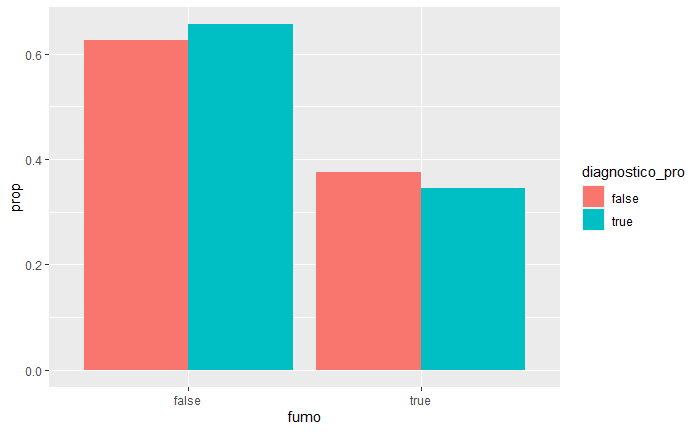

```r
datos_it2 %>%
  filter(!is.na(fumo)) %>%
  ggplot(aes(x = fumo, y = stat(prop), fill = diagnostico_pro, group = diagnostico_pro)) +
  geom_bar(position = "dodge")
```

Llegamos a la conclusión de que no parece existir gran diferencia entre ambos grupo. Vamos a observar si la cantidad de anios que fumo es distinta

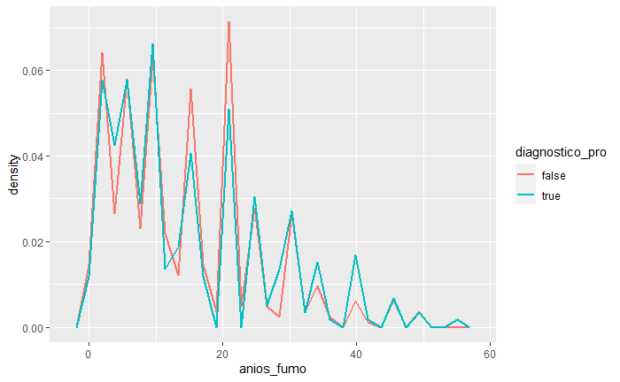

```r
datos_it2 %>%
  filter(!is.na(anios_fumo)) %>%
  ggplot(aes(x = anios_fumo, y = stat(density), color = diagnostico_pro)) +
  geom_freqpoly(size = 1.05)
```

Se observa que se sigue una tendencia para ambos grupos, sin mucha diferencia para los distintos valores de anios_fumo.

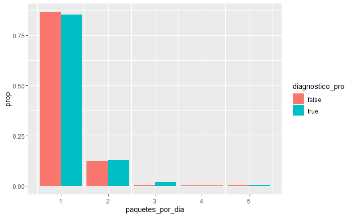

```r
datos_it2 %>%
  filter(!is.na(paquetes_por_dia)) %>%
  ggplot(aes(x = paquetes_por_dia, y = stat(prop), fill = diagnostico_pro)) +
  geom_bar(position = "dodge")
```

En la proporción de paquetes no parece haber ninguna diferencia entre los paquetes por día

En vista de los resultados obtenidos llegamos a la conclusión que no existe diferencia entre ambos grupos con respecto a fumar.

**¿Hay diferencia en las variables relacionadas con el celular?**

Comenzamos comparando las variables de facilidad_celular

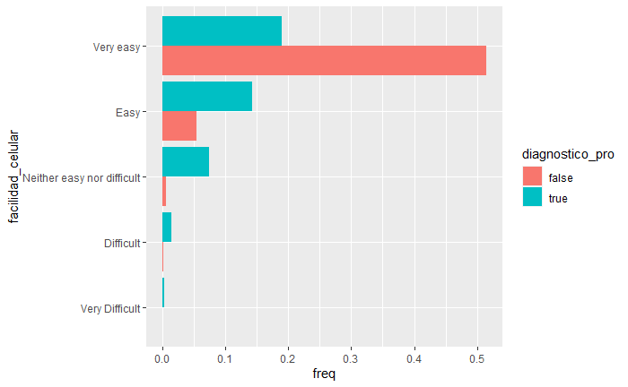

```r
datos_it2 %>%
  filter(!is.na(facilidad_celular)) %>%
  count(diagnostico_pro, facilidad_celular) %>%
  mutate(facilidad_celular = fct_reorder(facilidad_celular, n),
         freq = n / sum(n)) %>%
  ggplot(aes(facilidad_celular, freq, fill = diagnostico_pro)) +
  geom_bar(position = "dodge", stat = "identity") +
  coord_flip()
```

Encontramos diferencias entre ambos grupos. Cerca del 50% de las observaciones en el grupo sin diagnóstico profesional pertenecen a “very easy”, como se esperaba. En este mismo segmento de daignostico_pro es insignificante la proporción de observaciones que pertenecen a “neither esay nor difficult” o peor. En contraste, para el grupo con un diagnóstico positivo se observa que adquiere importancia personas en el grupo intermedio o tan sólo difícil.

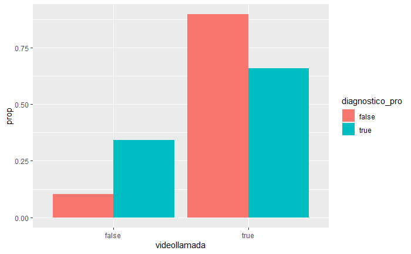

```r
datos_it2 %>%
  filter(!is.na(videollamada)) %>%
  ggplot(aes(videollamada, stat(prop), fill = diagnostico_pro, group = diagnostico_pro)) +
  geom_bar(position = "dodge")
```

Observamos que el porcentaje de personas que no realizan videollamadas es mayor en gente con diagnóstico positivo. Podría deberse a que mayor porcentaje de personas tienen dificultad o están en un punto intermedio para usar el celular?

**¿Hay diferencia de edades?**

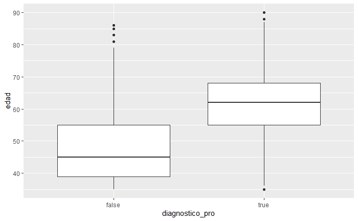

```r
ggplot(datos_it2, aes(diagnostico_pro, edad)) +
  geom_boxplot()
```

Hay una marcada diferencia de edades entre ambos grupos. Personas sin diagnóstico tienden a ser menores al otro grupo. Poseen una mediana cerca de los 45 años. El grupo con diagnóstico positivo tienen una mediana un poco mayor a 60 años. El rango intercuantil es mayor en el grupo “false”. Ambos niveles tienen outliers.

**Hay diferecia en los géneros**

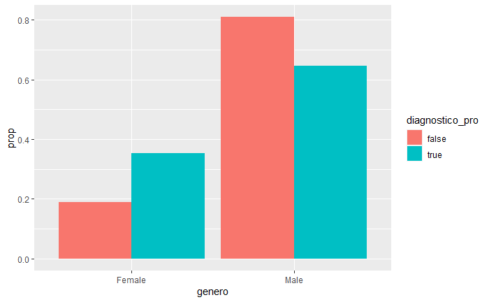

```r
datos_it2 %>%
  filter(genero != "Prefer not to answer") %>%
  ggplot(aes(genero, stat(prop), fill = diagnostico_pro, group = diagnostico_pro)) +
  geom_bar(position = "dodge")
```

Observamos que hay mucho mayor porcentahe de mujeres en el grupo con diagnóstico positivo. ¿Cambian las edades?

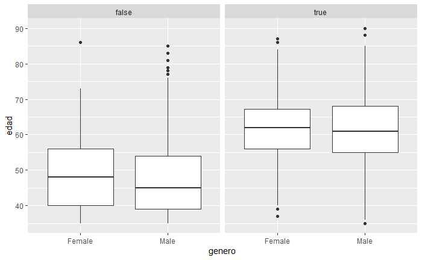

```r
datos_it2 %>%
  filter(genero != "Prefer not to answer") %>%
  ggplot(aes(genero, edad)) +
  geom_boxplot() +
  facet_wrap(~ diagnostico_pro)
```

Parece que se respetan las edades en los generos en ambos grupos.

**¿Las parejas son más propensos a tener parkinson?**

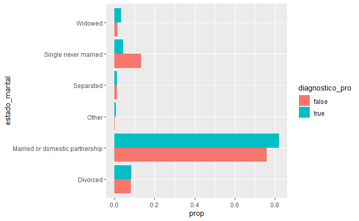

```r
datos_it2 %>%
  filter(!is.na(estado_marital)) %>%
  ggplot(aes(estado_marital, stat(prop), group = diagnostico_pro, fill = diagnostico_pro)) +
  geom_bar(position = "dodge") +
  coord_flip()
```

Observamos que el grupo sin diagnóstico profesional se desaca en “Single never married”, esto podría deberse a que la edad es menor en este grupo. En comparación la personas con diagnóstico positivo se destacan en “widowed” y “Married or domestic partnership”.

Para responder a la pregunta observamos dentro del grupo “Marreid or domestic partnership” cómo son las proporciones personas con dignóstico profesional del parkinson.

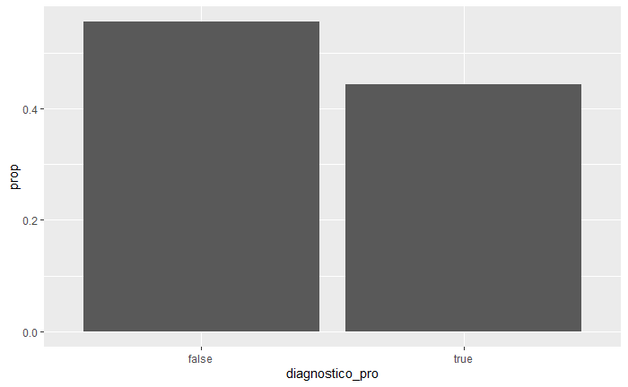

```r
datos_casados <- datos_it2 %>%
  filter(estado_marital == "Married or domestic partnership")

ggplot(datos_casados, aes(diagnostico_pro, stat(prop), group = 1)) +
  geom_bar()
```

Miramos ahora la proporción de generos aqui

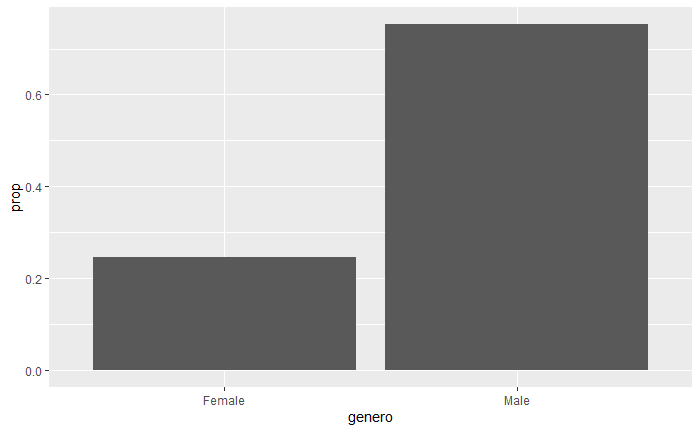

```r
datos_casados %>%
  filter(!is.na(genero) & genero != "Prefer not to answer") %>%
  ggplot(aes(genero, stat(prop), group = 1)) +
  geom_bar()
```

Observamos como hay una proporción mucho mayor de hombres en este grupo, lo que nos lleva a la pregunta ¿Cómo seran la proporciones de diagnostico_pro separando por sexo?

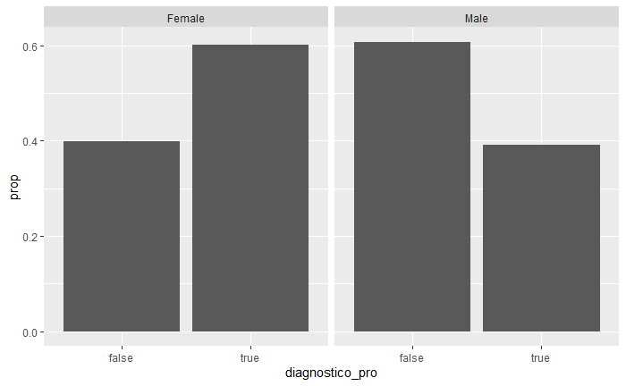

```r
datos_casados %>%
  filter(!is.na(genero) & genero != "Prefer not to answer") %>%
  ggplot(aes(diagnostico_pro, stat(prop), group = 1)) +
  geom_bar() +
  facet_grid(~genero)
```

```r
NA
```

Observamos que en este grupo, el 60% de las muejeres tiene diagnóstico postivo. En contraposición, el 60% de los hombres no tienen diagnóstico profesional.

Pero, capaza esta desproporción entre homres y muejeres pueda ser general de los datos, y nada específico de este subgrupo. Por lo que vamos a observar la tabla de contigencia entre estas variables.

```r
table(datos_it2$genero, datos_it2$estado_marital) %>%
  addmargins(c(1, 2))
```

```
                       Divorced Married or domestic partnership Other Separated Single never married Widowed  Sum
  Female                     61                             427     4         7                   44      31  574
  Male                      121                            1305     7        20                  165      19 1637
  Prefer not to answer        0                               1     0         0                    0       0    1
  Sum                       182                            1733    11        27                  209      50 2212
```

Aqui observamos que tanto el mayor número de mujeres como de hombres pertenecen a este grupo. Además, en todos los grupos, excepto en widowed, existe esta diferencia abrumadora entre hombres y muejeres.

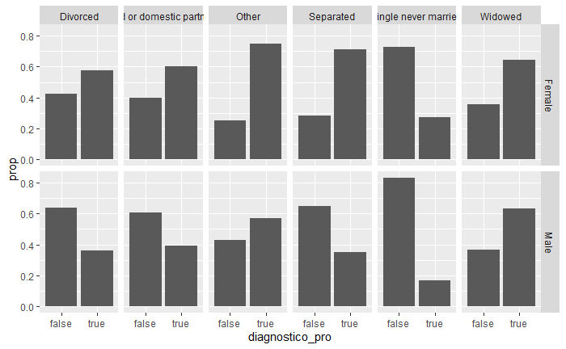

```r
datos_it2 %>%
  filter(!is.na(genero) & genero != "Prefer not to answer" & !is.na(estado_marital)) %>%
  ggplot(aes(diagnostico_pro, stat(prop), group = 1)) +
  geom_bar() +
  facet_grid( genero ~ estado_marital)
```